# Particle MCMC

Valencia International Bayesian Analysis Summer School Workshop

# Particle MCMC

Note that at each step, one can get a Monte Carlo estimate of $p(y_t|y_{1:t-1}, \theta)$, so one can multiply to estimate $p(y_{1:T}|\theta)$.

Recall that for MCMC,

- High-dimensional latent process values in non-conjugate models often result in bad mixing.
- Ideally, we’d like to integrate over $x_{1:T}$ and do MCMC only on hyperparameters, $\theta$.
- SMC algorithms allow us to estimate the marginal likelihood so could be embedded within MCMC for the hyperparameters.

# Particle MCMC in NIMBLE

NIMBLE provides scalar and block random-walk Metropolis Hastings based on this approach: “Particle Marginal Metropolis Hastings”.

Simply specify ‘RW_PF’ or ‘RW_PF_block’ in *addSampler*, indicating the $x_{1:T}$ nodes as part of the control argument.

The setup code creates a filtering algorithm, and then the run code runs it under the proposed hyperparameter values and uses the likelihood approximation in the Metropolis-Hastings acceptance calculation.

# Stochastic volatility example revisited

```r
stochVolCode <- nimbleCode({
  x[1] ~ dnorm(phi * x0, sd = sigma)
  y[1] ~ dnorm(0, var = betaSquared * exp(x[1]))
  for(t in 2:T){
        x[t] ~ dnorm(phi * x[t-1], sd = sigma)
        y[t] ~ dnorm(0, var = betaSquared * exp(x[t]))
  }
  x0 ~ dnorm(1, sd = sigma)
  phi <- 2 * phiStar - 1
  phiStar ~ dbeta(18, 1)
  sigma ~ T(dt(mu = 0, sigma = 1, df = 1), 0, )
  betaSquared <- beta^2
  beta ~ T(dt(mu = 0, sigma = 1, df = 1), 0, )
})
```

```r
library('stochvol')
data('exrates')
y <- 100 * logret(exrates$USD[exrates$date > '2012-02-01'])
stochVolModel <- nimbleModel(code = stochVolCode,
   constants = list(T = 44), data = list(y = y),
   inits = list(beta = .5992, phi = .9702,
   sigma = .178, x0 = 0))
```

```
## defining model...
```

```
## building model...
```

```
## setting data and initial values...
```

```
## running calculate on model (any error reports that follow may simply reflect missing values in model variables) ...
## checking model sizes and dimensions... This model is not fully initialized. This is not an error. To see which variables are not initialized, use model$initializeInfo(). For more information on model initialization, see help(modelInitialization).
## model building finished.
```

```r
CstochVolModel <- compileNimble(stochVolModel)
```

```
## compiling... this may take a minute. Use 'showCompilerOutput = TRUE' to see C++ compilation details.
## compilation finished.
```

# Stochastic volatility, particle MCMC

```r
stochVolConf <- configureMCMC(stochVolModel, nodes = NULL,
                              monitors = c('beta', 'phi', 'sigma' , 'x'))

stochVolConf$addSampler(target = c('beta', 'phiStar', 'sigma' , 'x0'),
                        type = 'RW_PF_block',
                        control = list(propCov = .1 * diag(4),
                                       pfType = 'auxiliary',
                                       pfControl = list(thresh = 1),
                                       adaptive = TRUE,
                                       pfNparticles = 200,
                                       latents = 'x',
                                       pfResample = TRUE)
                        )

stochVolMCMC <- buildMCMC(stochVolConf)
cMCMC <- compileNimble(stochVolMCMC, project = stochVolModel, resetFunctions = TRUE)
```

```
## compiling... this may take a minute. Use 'showCompilerOutput = TRUE' to see C++ compilation details.
```

```
## compilation finished.
```

```r
samples <- runMCMC(cMCMC, niter = 5000)
```

```
## running chain 1...
```

```
## |-------------|-------------|-------------|-------------|
## |-------------------------------------------------------|
```

# Stochastic volatility, particle MCMC results

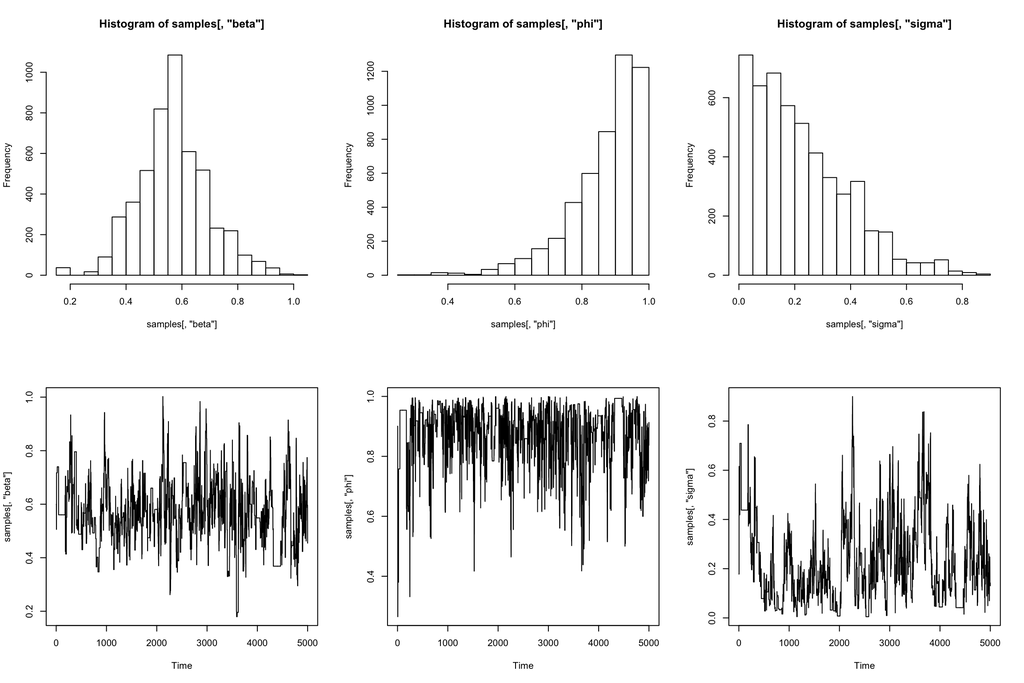

```r
par(mfrow = c(2, 3))
hist(samples[ , 'beta'])
hist(samples[ , 'phi'])
hist(samples[ , 'sigma'])
ts.plot(samples[ , 'beta'])
ts.plot(samples[ , 'phi'])
ts.plot(samples[ , 'sigma'])
```